# bivalency_analysis

Rohan Shah

7/15/2021

# Introduction

This R Markdown file is meant to streamline the analysis of the bivalency data and keep it organized in one place. Different types of analyses will be in different sections with explanations as to why those are important. This section will contain only data loading and functions that are necessary for downstream analyses.

## Data loading

This chunk loads in both the HMD data and the bulk RNA-seq data, as well as the tidyverse and sleuth libraries.

```r
library(topGO)
library(GO.db)
library(biomaRt)
library(tidyverse)
library(sleuth)

load("rdata/data_loaded.RData")
load("rdata/sleuth_loaded_bivalency_bulk-rna-seq.RData")

#Redo the HMDs for 0-400bp about the TSS

naive_hmd = data.frame(Gene = naive$k4$Gene)
naive_hmd$k4 = naive$k4 %>% select(X0:X400) %>% rowMeans
naive_hmd$k9 = naive$k9 %>% select(X0:X400) %>% rowMeans
naive_hmd$k27 = naive$k27 %>% select(X0:X400) %>% rowMeans
naive_hmd$cis = naive$cis %>% select(X0:X400) %>% rowMeans
naive_hmd$trans = naive$trans %>% select(X0:X400) %>% rowMeans
naive_hmd$Gene = as.character(naive_hmd$Gene)

primed_hmd = data.frame(Gene = primed$k4$Gene)
primed_hmd$k4 = primed$k4 %>% select(X0:X400) %>% rowMeans
primed_hmd$k9 = primed$k9 %>% select(X0:X400) %>% rowMeans
primed_hmd$k27 = primed$k27 %>% select(X0:X400) %>% rowMeans
primed_hmd$cis = primed$cis %>% select(X0:X400) %>% rowMeans
primed_hmd$trans = primed$trans %>% select(X0:X400) %>% rowMeans
primed_hmd$Gene = as.character(primed_hmd$Gene)

npc_hmd = data.frame(Gene = npc$k4$Gene)
npc_hmd$k4 = npc$k4 %>% select(X0:X400) %>% rowMeans
npc_hmd$k9 = npc$k9 %>% select(X0:X400) %>% rowMeans
npc_hmd$k27 = npc$k27 %>% select(X0:X400) %>% rowMeans
npc_hmd$cis = npc$cis %>% select(X0:X400) %>% rowMeans
npc_hmd$trans = npc$trans %>% select(X0:X400) %>% rowMeans
npc_hmd$Gene = as.character(npc_hmd$Gene)

hmds = list()
hmds[["naive"]] = naive_hmd
hmds[["primed"]] = primed_hmd
hmds[["npc"]] = npc_hmd

rm(naive_hmd, primed_hmd, npc_hmd)

tss_range = seq(-3, 3, by = 0.05)

sleuth_objs = list()
sleuth_objs[["all"]] = so_all
sleuth_objs[["naive_npc"]] = so_naive_npc
sleuth_objs[["naive_primed"]] = so_naive_primed
sleuth_objs[["primed_npc"]] = so_primed_npc

rm(so_all, so_naive_npc, so_naive_primed, so_primed_npc)

rm(metadata_naive_npc, metadata_naive_primed, metadata_primed_npc)
```

The next chunk loads in functions to make metagenes.

```r
get_biv_genes = function(dataset, threshold){
  genes = (dataset %>% filter(trans > threshold))$Gene
  return(genes)
}

metagene = function(dataset, range, genes){
  dataset_names = names(dataset)
  summ_df = data.frame(dist = range)

  for (i in dataset_names){
    summ_df[,i] = as.numeric(dataset[[i]] %>% filter(Gene %in% genes) %>% dplyr::select(-1) %>% summarize(across(.fns = mean)))
  }

  return(summ_df)
}

metagene_plot = function(summ_df, ylims = NA, title = NA){
  summ_plt = summ_df %>% gather("mod", "hmd", -dist)
  plot_summary = ggplot(data = summ_plt, aes(x = dist, y = hmd, color = mod)) + geom_line() + theme_classic()

  if (!is.na(ylims)){ plot_summary = plot_summary + scale_y_continuous(limits = ylims) }

  if (!is.na(title)){ plot_summary = plot_summary + ggtitle(title) }

  print(plot_summary)
}
```

# First-Pass HMD Metagene Analysis

First, we have to have a sense of how bivalency exists at all genes. To do this, we will plot metagenes of all genes for all samples.

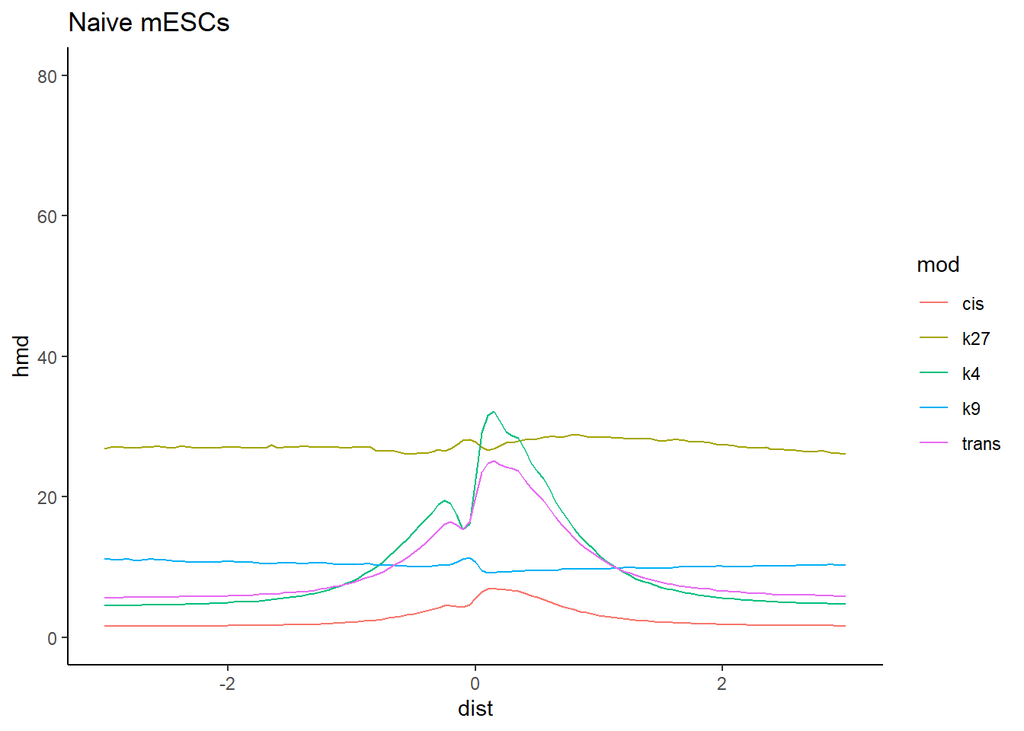

```r
metagene_plot(metagene(naive, tss_range, consensusGenes), ylims = c(0,80), title = "Naive mESCs")
```

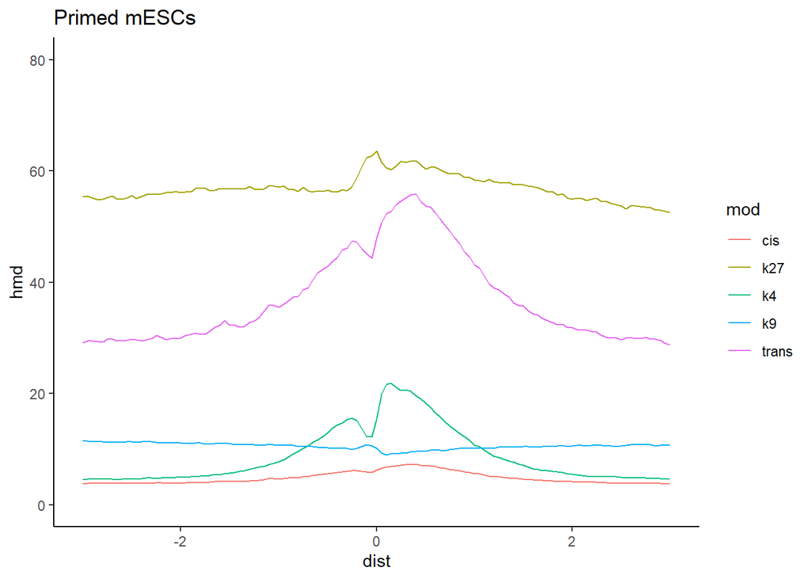

```r
metagene_plot(metagene(primed, tss_range, consensusGenes), ylims = c(0,80), title = "Primed mESCs")
```

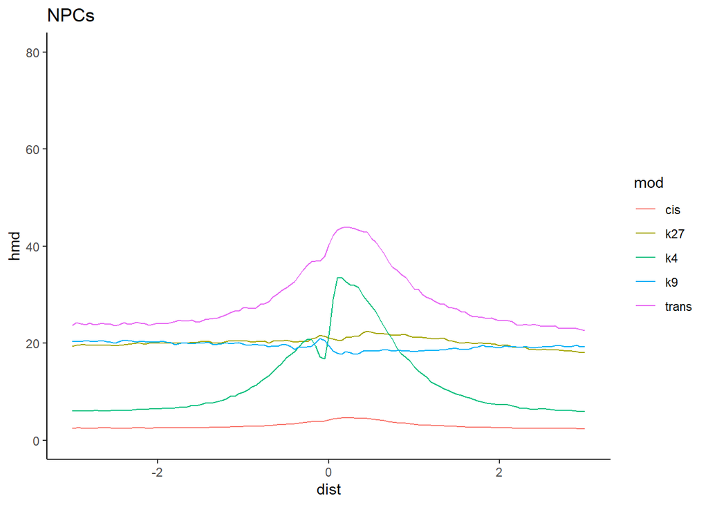

```r
metagene_plot(metagene(npc, tss_range, consensusGenes), ylims = c(0,80), title = "NPCs")
```

We observe that there is a significant amount of bivalency (especially trans bivalency) at all genes from naive, primed, and NPC samples. Importantly, it seems that bivalency actually *increases* over time rather than decreasing. This is interesting. My next step is to identify the average amount of bivalency in each of these samples – and that of all other modifications, while I’m at it.

```r
hmd_summary_precursor = hmds[["naive"]] %>% mutate(sample = "naive") %>% select(sample, k4:trans)
hmd_summary_precursor = rbind(hmd_summary_precursor, (hmds[["primed"]] %>% mutate(sample = "primed") %>% select(sample, k4:trans)))
hmd_summary_precursor = rbind(hmd_summary_precursor, (hmds[["npc"]] %>% mutate(sample = "npc") %>% select(sample, k4:trans)))

hmd_summary_all_genes = hmd_summary_precursor %>% group_by(sample) %>% summarize(across(.fns = mean))
print("HMD Summary Mean")
```

```
## [1] "HMD Summary Mean"
```

```r
print(hmd_summary_all_genes)
```

```
## # A tibble: 3 x 6
##   sample    k4    k9   k27   cis trans
##   <chr>  <dbl> <dbl> <dbl> <dbl> <dbl>
## 1 naive   28.7  9.44  27.3  6.51  23.5
## 2 npc     30.5 18.1   21.1  4.49  42.9
## 3 primed  20.1  9.35  61.3  6.91  53.1
```

```r
hmd_summary_all_genes = hmd_summary_precursor %>% group_by(sample) %>% summarize(across(.fns = median))
print("HMD Summary Median")
```

```
## [1] "HMD Summary Median"
```

```r
print(hmd_summary_all_genes)
```

```
## # A tibble: 3 x 6
##   sample    k4    k9   k27   cis trans
##   <chr>  <dbl> <dbl> <dbl> <dbl> <dbl>
## 1 naive   24.7  8.38  20.0  5.09  18.4
## 2 npc     21.5 15.9   16.0  3.14  30.1
## 3 primed  18.0  8.17  53.6  5.39  41.5
```

```r
rm(hmd_summary_precursor, hmd_summary_all_genes)
```

```r
bivalent_genes_10 = list()
bivalent_genes_25 = list()
bivalent_genes_50 = list()

bivalent_genes_10[["naive"]] = get_biv_genes(hmds[["naive"]], 10)
bivalent_genes_25[["naive"]] = get_biv_genes(hmds[["naive"]], 25)
bivalent_genes_50[["naive"]] = get_biv_genes(hmds[["naive"]], 50)

bivalent_genes_10[["primed"]] = get_biv_genes(hmds[["primed"]], 10)
bivalent_genes_25[["primed"]] = get_biv_genes(hmds[["primed"]], 25)
bivalent_genes_50[["primed"]] = get_biv_genes(hmds[["primed"]], 50)

bivalent_genes_10[["npc"]] = get_biv_genes(hmds[["npc"]], 10)
bivalent_genes_25[["npc"]] = get_biv_genes(hmds[["npc"]], 25)
bivalent_genes_50[["npc"]] = get_biv_genes(hmds[["npc"]], 50)
```

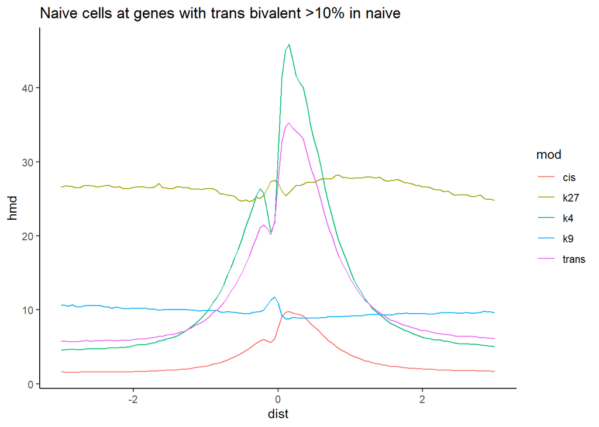

```r
metagene_plot(metagene(naive, tss_range, bivalent_genes_10[["naive"]]), title = "Naive cells at genes with trans bivalent >10% in naive")
```

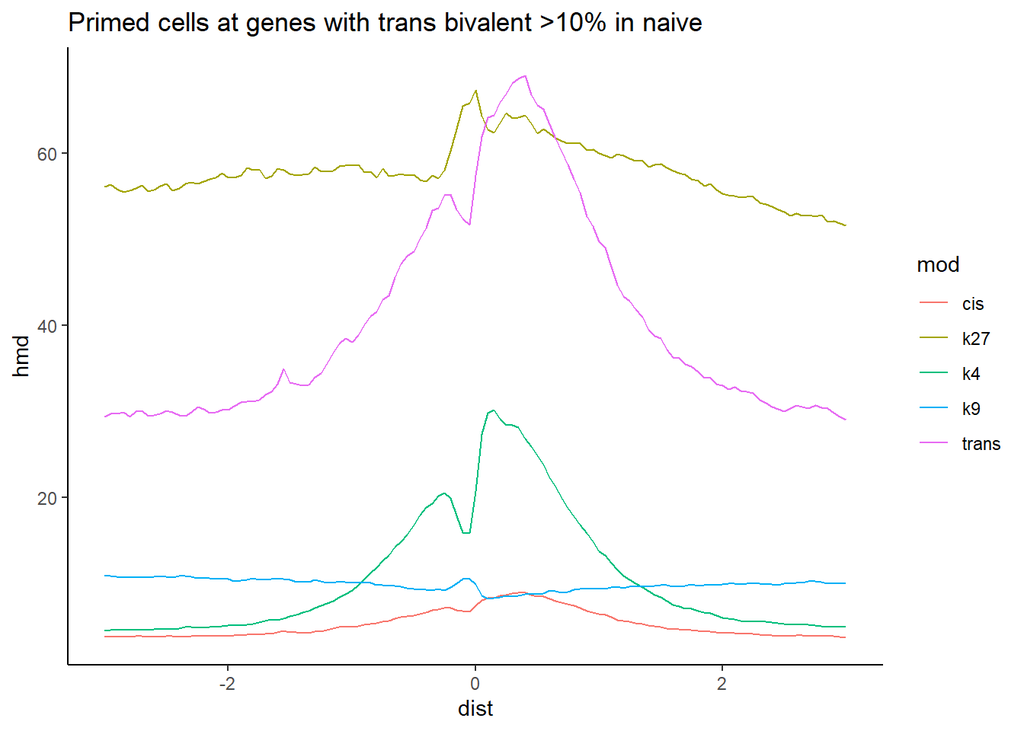

```r
metagene_plot(metagene(primed, tss_range, bivalent_genes_10[["naive"]]), title = "Primed cells at genes with trans bivalent >10% in naive")
```

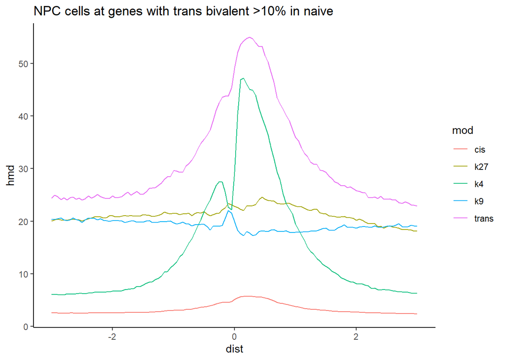

```r
metagene_plot(metagene(npc, tss_range, bivalent_genes_10[["naive"]]), title = "NPC cells at genes with trans bivalent >10% in naive")
```

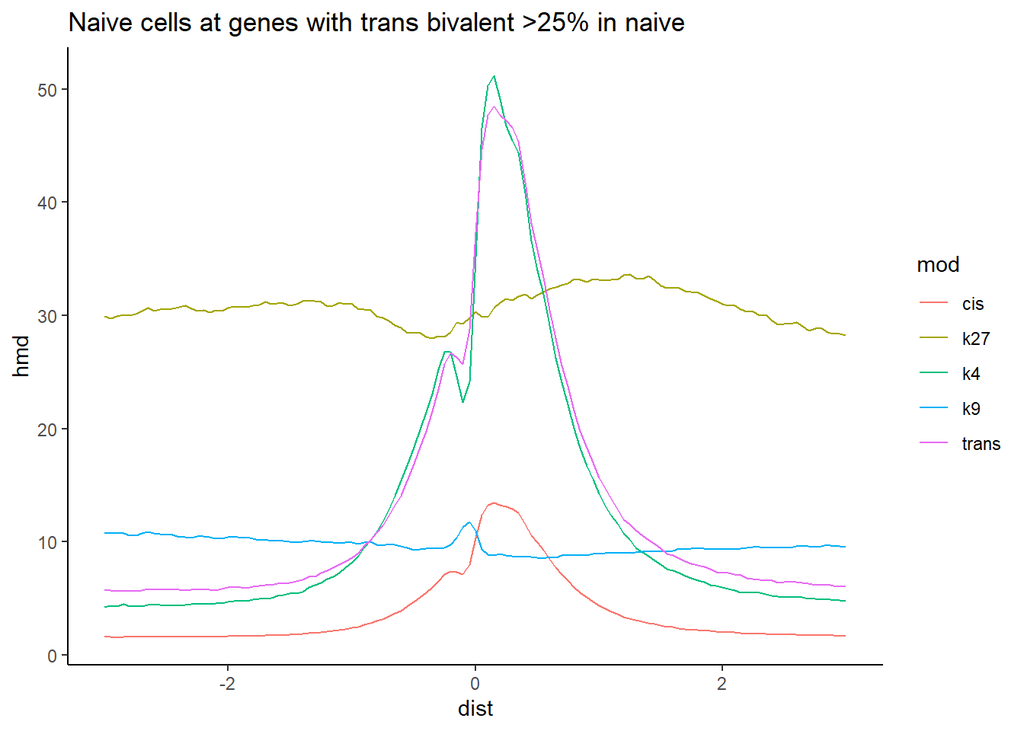

```r
metagene_plot(metagene(naive, tss_range, bivalent_genes_25[["naive"]]), title = "Naive cells at genes with trans bivalent >25% in naive")
```

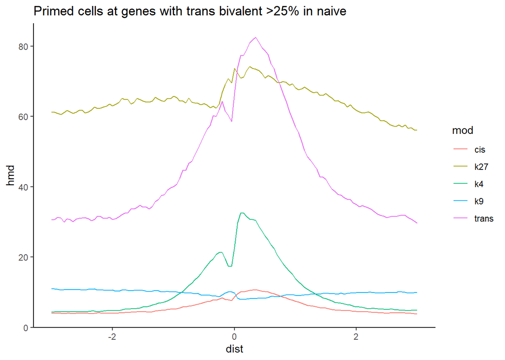

```r
metagene_plot(metagene(primed, tss_range, bivalent_genes_25[["naive"]]), title = "Primed cells at genes with trans bivalent >25% in naive")
```

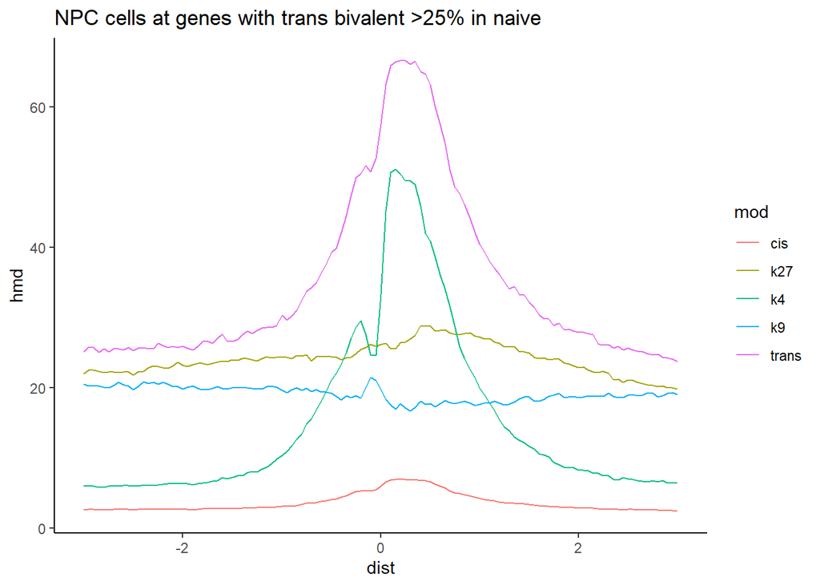

```r
metagene_plot(metagene(npc, tss_range, bivalent_genes_25[["naive"]]), title = "NPC cells at genes with trans bivalent >25% in naive")
```

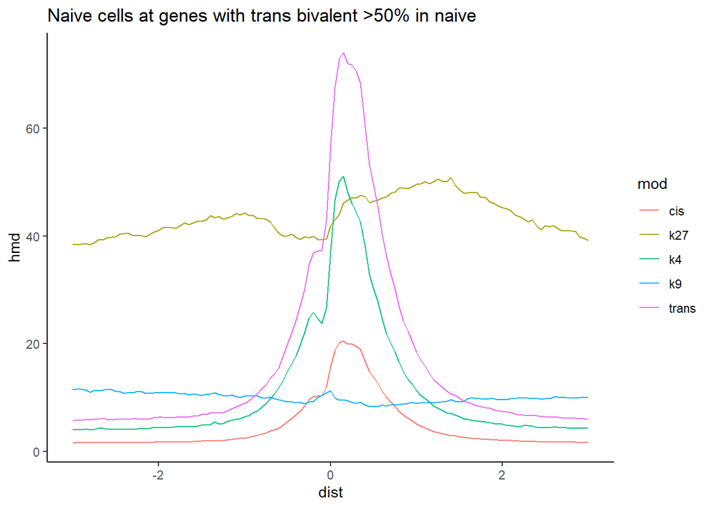

```r
metagene_plot(metagene(naive, tss_range, bivalent_genes_50[["naive"]]), title = "Naive cells at genes with trans bivalent >50% in naive")
```

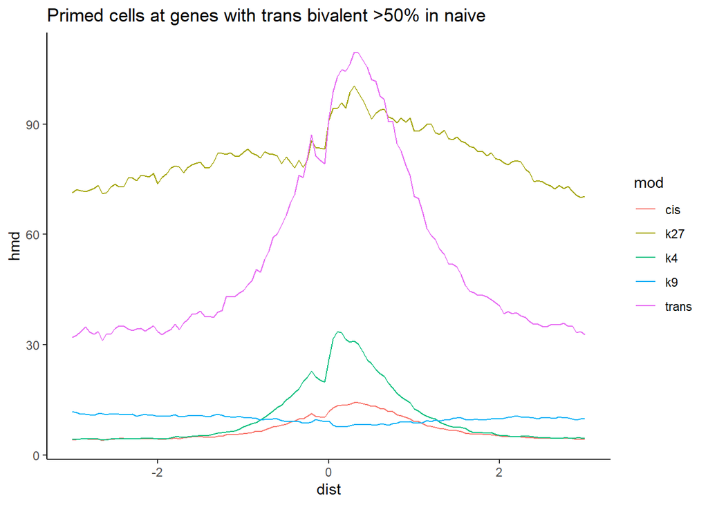

```r
metagene_plot(metagene(primed, tss_range, bivalent_genes_50[["naive"]]), title = "Primed cells at genes with trans bivalent >50% in naive")
```

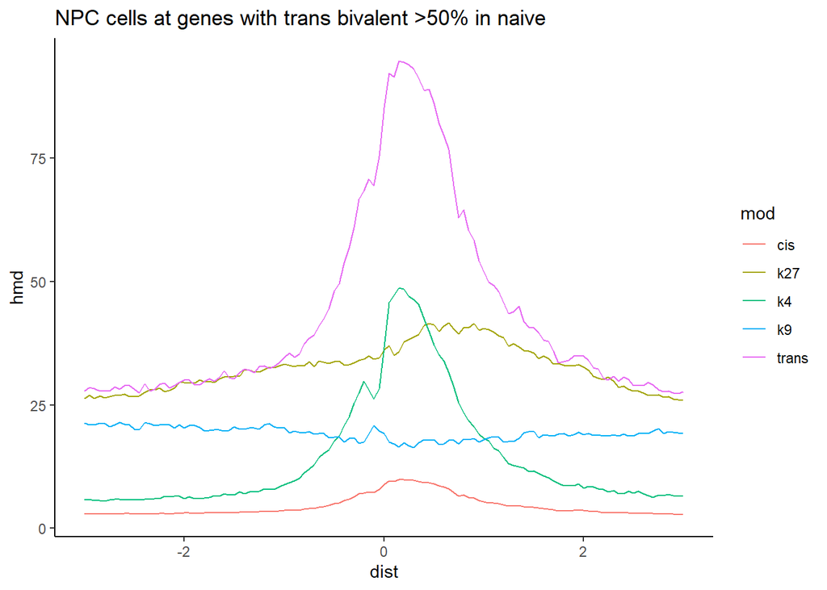

```r
metagene_plot(metagene(npc, tss_range, bivalent_genes_50[["naive"]]), title = "NPC cells at genes with trans bivalent >50% in naive")
```

Basically, no matter how we call it, bivalent genes seem to broadly stay bivalent.

## Dominance sectioning

Let’s see if sectioning this by K27 dominant bivalency or K4 dominant bivalency in the naive dataset helps at all.

```r
naive_dominance = list()
hmds[["naive"]] = hmds[["naive"]] %>% mutate(logratio = log(k27+1) - log(k4+1))
naive_dominance[["k27"]] = (hmds[["naive"]] %>% filter(trans > 25) %>% filter(logratio > 1))$Gene
naive_dominance[["k4"]] = (hmds[["naive"]] %>% filter(trans > 25) %>% filter(logratio < -1))$Gene
naive_dominance[["mid"]] = (hmds[["naive"]] %>% filter(trans > 25) %>% filter(logratio <= 1 & logratio >= -1))$Gene
```

Overall, we see that with an $e^1$ ratio threshold (logratio 1), there are 1728 K27 dominant genes, 6335 K4 dominant genes, and 7704 neutral genes with a bivalency threshold of 25%. Of course, we now want to do metagene analysis.

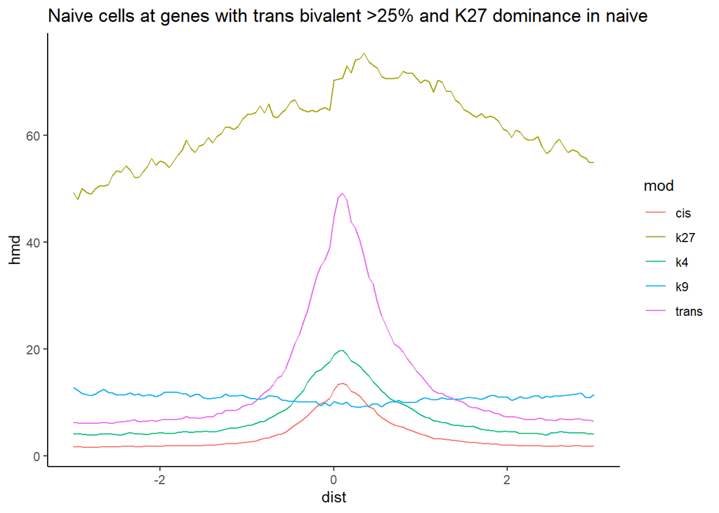

```r
metagene_plot(metagene(naive, tss_range, naive_dominance[["k27"]]), title = "Naive cells at genes with trans bivalent >25% and K27 dominance in naive")
```

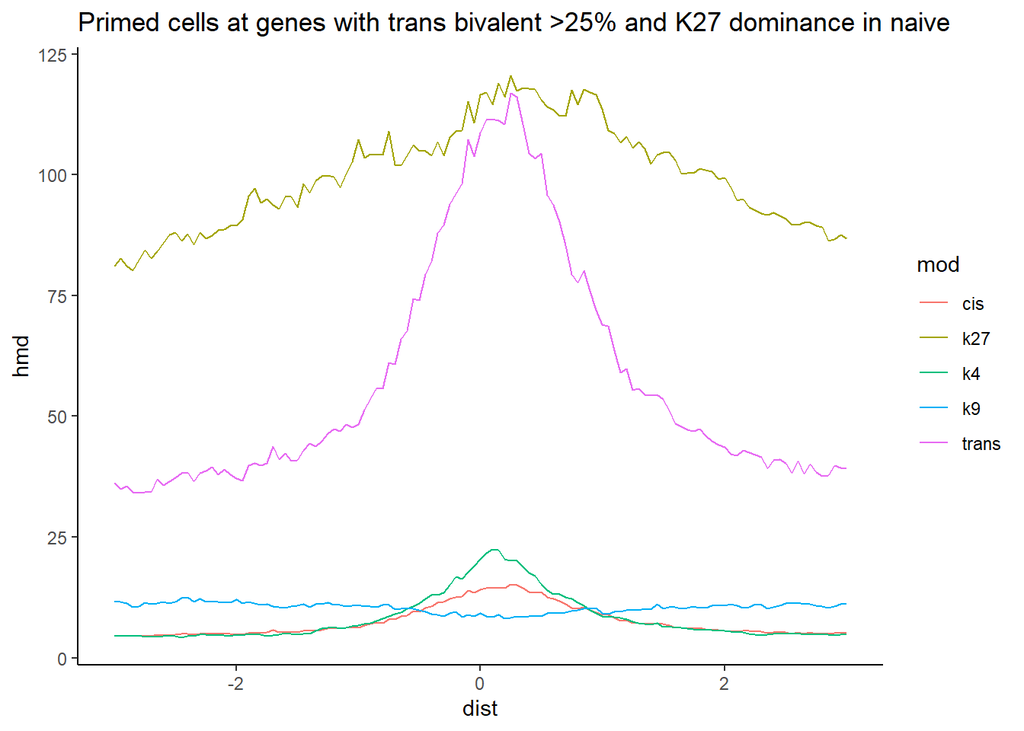

```r
metagene_plot(metagene(primed, tss_range, naive_dominance[["k27"]]), title = "Primed cells at genes with trans bivalent >25% and K27 dominance in naive")
```

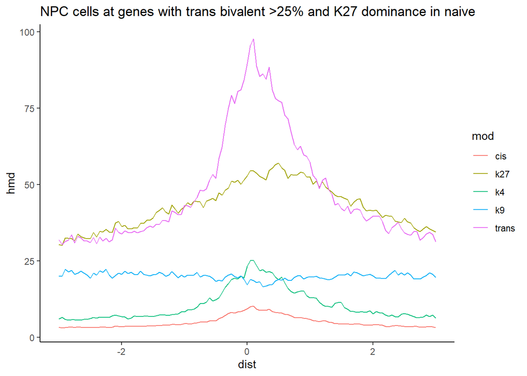

```r
metagene_plot(metagene(npc, tss_range, naive_dominance[["k27"]]), title = "NPC cells at genes with trans bivalent >25% and K27 dominance in naive")
```

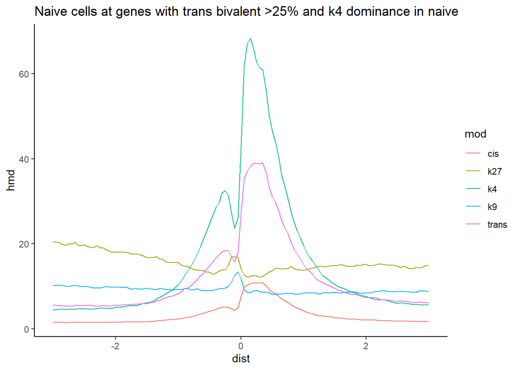

```r
metagene_plot(metagene(naive, tss_range, naive_dominance[["k4"]]), title = "Naive cells at genes with trans bivalent >25% and k4 dominance in naive")
```

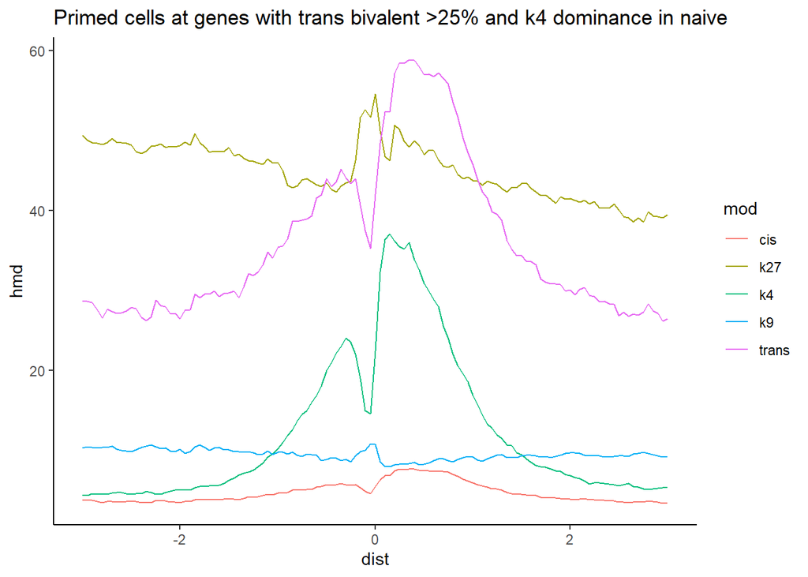

```r
metagene_plot(metagene(primed, tss_range, naive_dominance[["k4"]]), title = "Primed cells at genes with trans bivalent >25% and k4 dominance in naive")
```

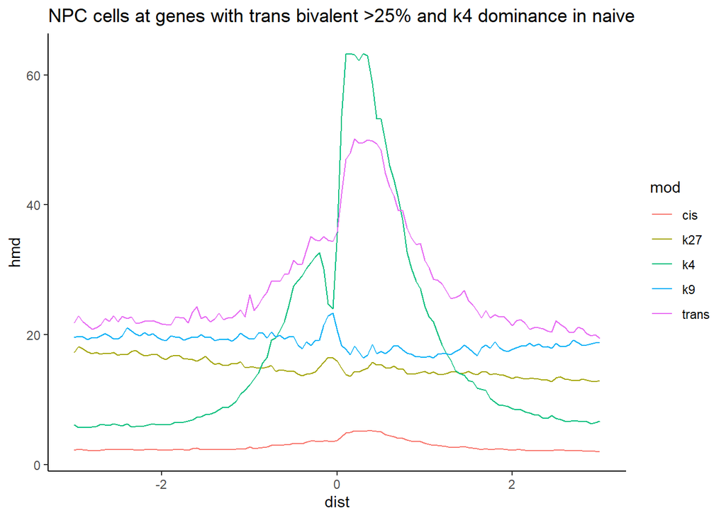

```r
metagene_plot(metagene(npc, tss_range, naive_dominance[["k4"]]), title = "NPC cells at genes with trans bivalent >25% and k4 dominance in naive")
```

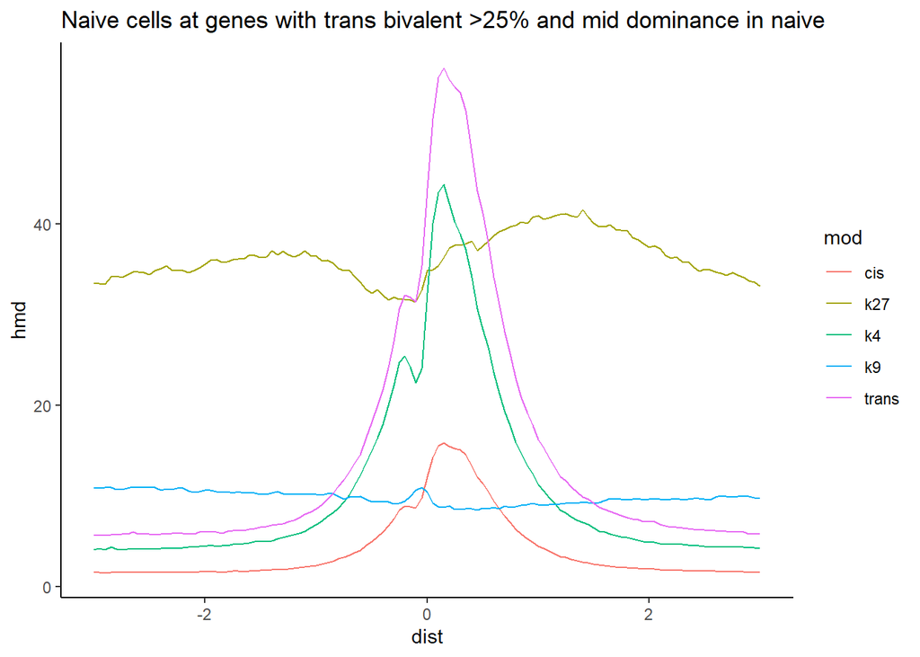

```r
metagene_plot(metagene(naive, tss_range, naive_dominance[["mid"]]), title = "Naive cells at genes with trans bivalent >25% and mid dominance in naive")
```

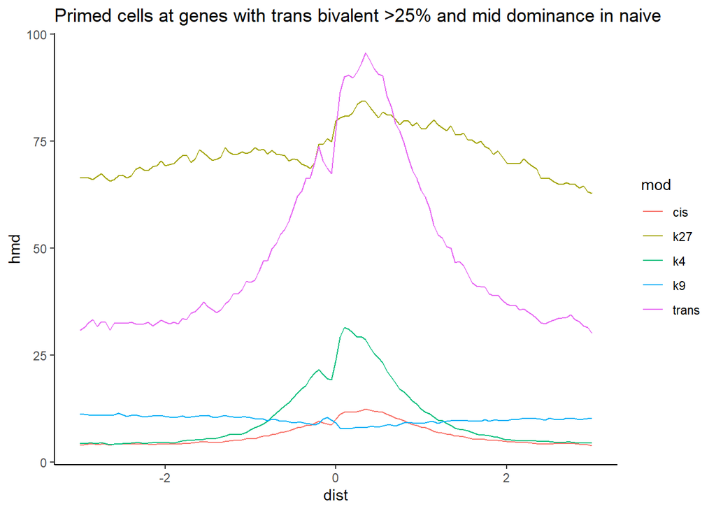

```r
metagene_plot(metagene(primed, tss_range, naive_dominance[["mid"]]), title = "Primed cells at genes with trans bivalent >25% and mid dominance in naive")
```

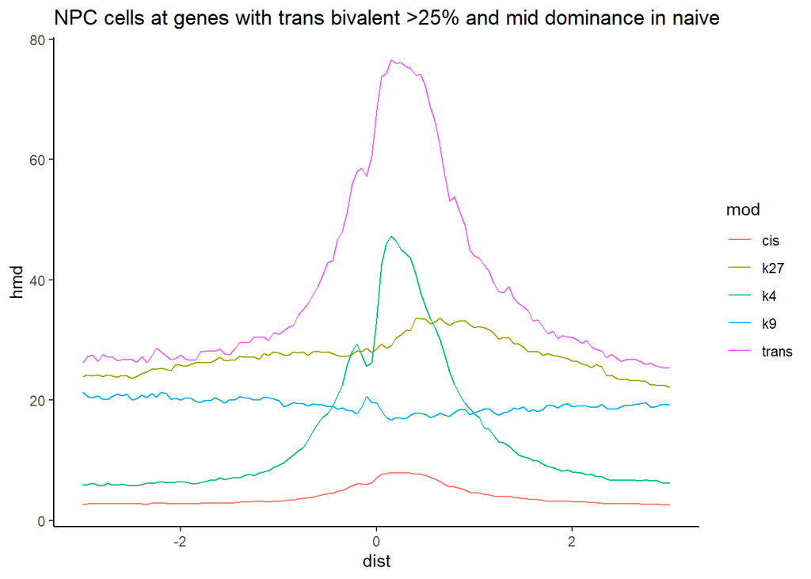

```r
metagene_plot(metagene(npc, tss_range, naive_dominance[["mid"]]), title = "NPC cells at genes with trans bivalent >25% and mid dominance in naive")
```

Overwhelmingly, it again seems that across these bivalency dominance classes, bivalent genes remain bivalent.

# Gene Ontology Setup

My next goal will be to conduct metagene analysis on differnet gene ontologies. The goal here will be to load up the gene ontology files and accessions so that I don’t have to download it again in the future.

```r
if (!file.exists("rdata/go_terms.RData")){
  ensembl = biomaRt::useMart("ENSEMBL_MART_ENSEMBL", dataset = "mmusculus_gene_ensembl")
  attributes = biomaRt::listAttributes(ensembl)
  filters = biomaRt::listFilters(ensembl)

  go_refseq_mrna = biomaRt::getBM(attributes = c('refseq_mrna', 'ensembl_gene_id', 'external_gene_name', 'go_id'), filters = 'with_refseq_mrna', values = TRUE, mart = ensembl)

  go_refseq_ncrna = biomaRt::getBM(attributes = c('refseq_ncrna', 'ensembl_gene_id', 'external_gene_name', 'go_id'), filters = c('with_refseq_mrna', 'with_refseq_ncrna'), values = list(FALSE, TRUE), mart = ensembl)

  colnames(go_refseq_mrna) = c('refseq_id', 'ensembl_gene_id', 'external_gene_name', 'go_id')
  colnames(go_refseq_ncrna) = c('refseq_id', 'ensembl_gene_id', 'external_gene_name', 'go_id')
  refseq_ensembl_external_go = rbind(go_refseq_mrna, go_refseq_ncrna) %>% filter(refseq_id != "") %>% filter(go_id != "")

  refseq_with_go = refseq_ensembl_external_go$refseq_id %>% unique
  ensembl_with_go = refseq_ensembl_external_go$ensembl_gene_id %>% unique
  genename_with_go = (refseq_ensembl_external_go %>% filter(external_gene_name != ""))$external_gene_name %>% unique

  rm(ensembl, attributes, filters, go_refseq_mrna, go_refseq_ncrna)
  save.image("rdata/go_terms.RData")
} else {
  load("rdata/go_terms.RData")
}
```

We now have GO ids for Refseq, Ensembl, and external gene names in M. musculus. The next thing to do is to assemble lists of the GO terms for each class of genes that we will be interested in.

First, we will want to get GO terms and their offspring for developmental processes, embryo development, and maintenance of pluripotency. Then, we will examine the metabolic processes. As a negative control, so to speak, we will also pull out terms for immune system processes. Finally, we will get GO terms for neurodevelopmental processes, as these genes should be “turned on” over differentiation to NPCs.

```r
go_ids = list()

go_ids[["developmental_processes"]] = c(GO.db::GOBPOFFSPRING[["GO:0032502"]], "GO:0032502")
go_ids[["embryo_development_ids"]] = c(GO.db::GOBPOFFSPRING[["GO:0009790"]], "GO:0009790")
go_ids[["maintenance_pluripotency"]] = c(GO.db::GOBPOFFSPRING[["GO:0019827"]], "GO:0019827")

go_ids[["metabolic_processes"]] = c(GO.db::GOBPOFFSPRING[["GO:0008152"]], "GO:0008152")

go_ids[["immune_system"]] = c(GO.db::GOBPOFFSPRING[["GO:0002376"]], "GO:0002376")

go_ids[["neuron_differentiation"]] = c(GO.db::GOBPOFFSPRING[["GO:0030182"]], "GO:0030182")
```

All told, we now have GO term IDs for each of our classes of interest stored in the list go_ids.

# Sectioning Metagenes with Gene Ontology

We will now use the different gene ontology terms we have just identified to create metagene plots across different GO term classes.